სმკმ: მეექვსე შეხვედრა

# სოციალურ მეცნიერებათა კვლევის მეთოდები

დავით სიჭინავა  
9 აპრილი, 2020 წ.

მეექვსე შეხვედრა

### დღევანდელი შეხვედრის გეგმა

- ფოკუს-ჯგუფი

### ფოკუს-ჯგუფის ფილოსოფია

- ,,ჯგუფური სიღრმისეული ინტერვიუ“
- გულახდილობა - გადამდებია

### ფოკუსჯგუფის ფილოსოფია

- ინტერვიუსგან განსხვავებით, ფოკუსჯგუფები კონკრეტულ, სპეციფიურ თემას შეისწავლიან და ამ საკითხის ირგვლივ ამომწურავ პასუხს გვაძლევენ
- ფოკუსჯგუფების შემთხვევაში, ადამიანები საკითხებს განიხილავენ როგორც *ჯგუფის ნაწილი* - ამ შემთხვევაში, მკვლევარი შეიძლება, დაინტერესდეს, თუ როგორ პასუხობენ ისინი ერთმანეთის შეხედულებებს

### ფოკუსჯგუფის ფილოსოფია

- *ფოკუსირებული* ინტერვიუ (მერტონი, 1956)
- მეთოდი საშუალებას იძლევა, ჩავწვდეთ, თუ რატომ აქვთ ადამიანებს ესა თუ ის შეხედულება - ჯგუფური დინამიკა
- ფოკუსჯგუფის დისკუსიისას, რესპონდენტებს შეუძლიათ, ერთმანეთი ,,გამოიწვიონ'', რაც ინტერვიუს მსვლელობისას ნაკლებადაა შესაძლებელი

### სად გამოიყენება ფოკუს-ჯგუფები?

- მარკეტინგი და ბაზრის კვლევა;
- პოლიტიკის კვლევა;
  - ,,გამოყენებითი ასპექტი''
- ქალაქგეგმარება (ე.წ. ჩართული დაგეგმვა);

### სად გამოიყენება ფოკუს-ჯგუფები?

- სოციალური გარიყვის კვლევა საქართველოში (მსოფლიო ბანკი, 2016)

[figure not shown]

### სად გამოიყენება ფოკუს-ჯგუფები?

- დაბრუნებული მიგრანტების კვლევა (DRC, 2007)

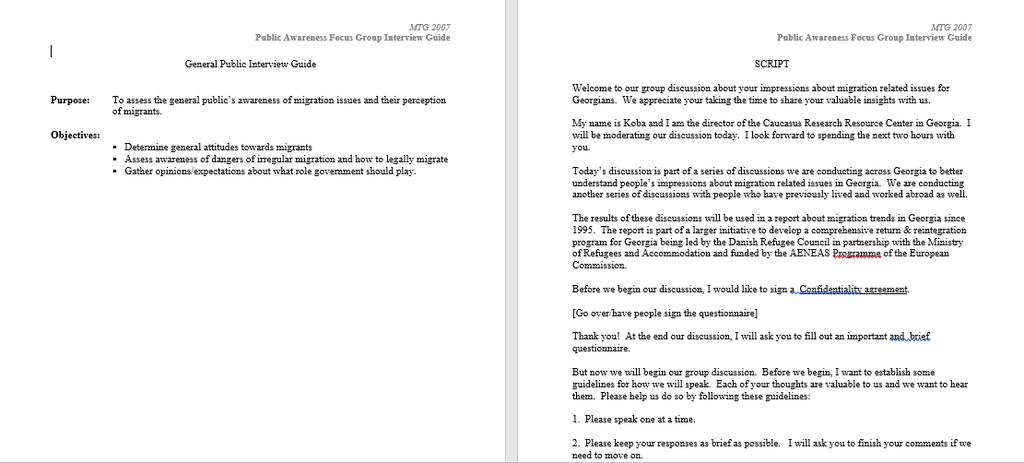

### სად გამოიყენება ფოკუს-ჯგუფები?

- დაბრუნებული მიგრანტების კვლევა (DRC, 2007)

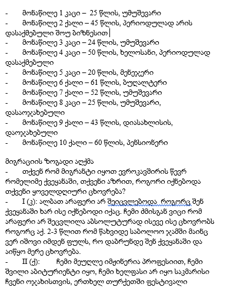

### მეთოდის დახასიათება

- რაოდენობა
- შერჩევა
- დისკუსიის წარმართვა (მოდერაცია)
  - მოდერატორი
  - სადისკუსიო გეგმა

### მეთოდის დახასიათება

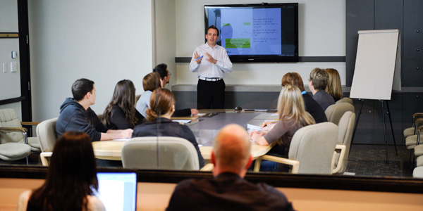

წყარო: http://www.pra.ca/en/focus-group-facility

### პროექციული ტექნიკები:

- სიტყვიერი ასოციაცია;
- წინადადების დამთავრება;
- კითხვები ,,მესამე პირში";
- პერსონიფიკაცია;
- ღრუბლიანი ნახატები;
- სტერეოტიპები;
- როლები;
- ნახატები და ,,ფსიქონახატები'';
- კოლაჟი;
- კარტოგრაფირება;

### ზონდირება:

- სიჩუმე;
- ჟესტების ენა;
- ჯგუფის მართვა;

### რა უნდა გავითვალისწინოთ:

- როგორ წარვუდგენთ კვლევას მონაწილეებს?
- გამოყენებული კითხვები საშუალებას იძლევა, საკითხი სათანადოდ გამოვიკვლიოთ?
- სადისკუსიო გეგმა შემოწმებულია? ენობრივად გამართულია?
- მოფიქრებული კითხვები დისკუსიას ახალისებს, თუ - უბრალოდ ,,დიახ/არა'' ტიპისაა?
- რას ვაკეთებთ, თუკი ჯგუფის დისკუსია ისე არ მიდის, როგორც თავდაპირველად გავთვალეთ?
- რა დამატებით მასალას ვიყენებთ დისკუსიის წასახალისებლად?